# Word Prediction Application - John's Hopkins University Capstone Project

jbratanov  
09-Sep-2016

### Introduction

Our goal is to build a predictive text pattern algorithm using Natural Language Processing to predict the next word or set of words as users type real time.

The data is from a corpus called HC Corpora and is located at www.corpora.heliohost.org.

Three types of datasets are used to train the model: Twitter, news and blogs, each Coprus file containing about 200 MB of text.

The use of N-Grams and a back-off predictive algorithm was applied to predict next word(s). The final predictive model was optimized to work within the boundaries of the shiny.io cloud site as a Shiny application.

### Data Exploration and Cleaning

The following steps were executed to clean and refine very large twitter, news and blogs files.

- 70% of the original data was randomly selected from the three sources and merged into one training dataset.
- Data cleaning involved converting to lower case, removing punctuations, white space, numbers and non ASCII characters.
- 3 files of n-grams were created with 2,3 and 4 word phrases.
- Phrase frequencies were calculated and sorted in descending order.
- Smoothing of data removed frequencies of less than 5 for each ngram to reduce their size for best performance.

### Natural Language Prediction Model

The next word prediction model is based on a Back-off algorithm. Here are the steps involved in predicting the next word of the user specified sentence

- Load 3 R-compressed n-gram data sets into a trie digital data structure for quick data access and retrieval
- Clean user input to match similar cleaning as ngram datasets.
- Use highest number of words to determine which ngram level to start with before back-off to next level. Highest level of words in a phrase is last 3 words. Back-off means nothing found, so drop a word and use 2 words. Last level is 1 word, after that, no words return. Future enhancement should add manually typed word not in ngrams into a users Corpus for future prediction use.

### Word Prediction Shiny Application

Below is a screenshot of the shiny application

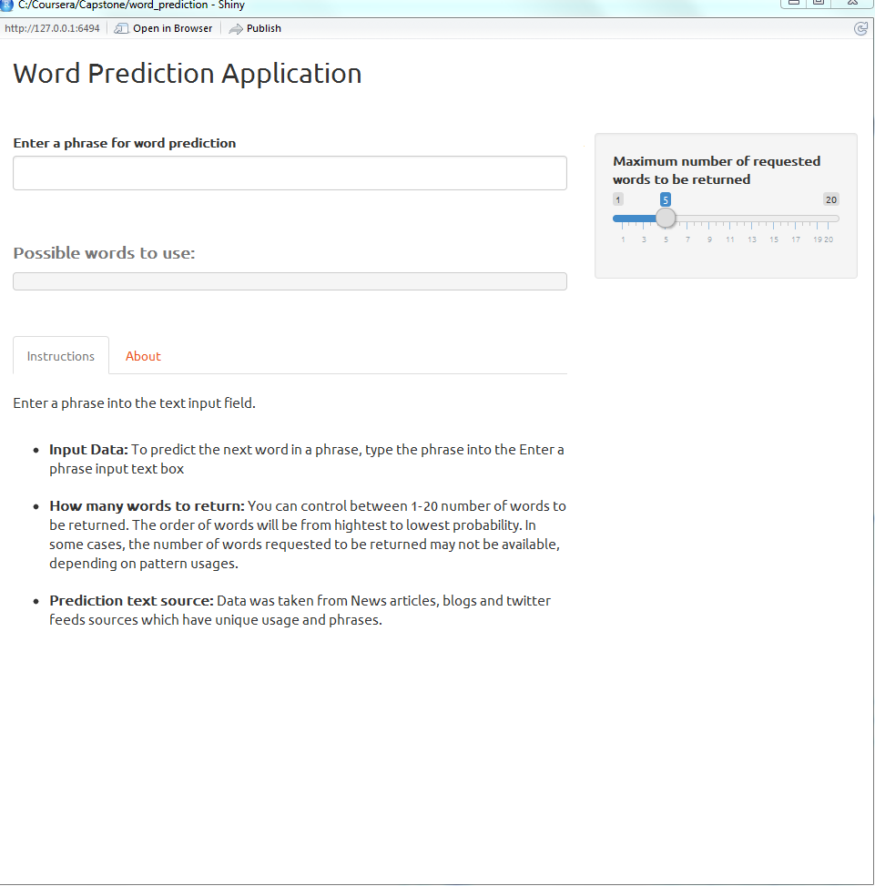

[Click Here to Try Application](https://jbratanov.shinyapps.io/word_prediction/)